# HR analitycs

Gabor Gehl

februar 26, 2017

### Content

This document contains a short analysis of a HR dataset from KAGGLE. The main content of the dokument

- Understand the business value of the data - quick data review
- Some exploratory data analysis on the available variable
- Model predictions
- Diagnostics

The original URL of the public dataset is https://www.kaggle.com/ludobenistant/hr-analytics .

### Understand the business value of the data - quick data review

The first look at the data and a quick check of all columns. Minimum and maximum values, means and medians.  
The table contains the basic statistical information of each feature. We can see that people working on 3-4 project and have around 200 hours working houtrs by month on average.  
The minimum time spent on the company is 2 years, the maximum is around 10 years and the average is about 3.5 years.  
The salaries are in three categories. Low, medium and high.  
Employees who left the company is marked with ‘1’. With this label we can make a separate group of them. We can analyse this group and compare them to the whole group.

### Data summary

```
## [1] "C:/Users/Géhl Gábor/Documents/Text/G/Study/CEU Study/2016-2017/DA for Business/Homework/HR Analytics"
```

```
##  satisfaction_level last_evaluation  number_project  average_montly_hours
##  Min.   :0.0900     Min.   :0.3600   Min.   :2.000   Min.   : 96.0
##  1st Qu.:0.4400     1st Qu.:0.5600   1st Qu.:3.000   1st Qu.:156.0
##  Median :0.6400     Median :0.7200   Median :4.000   Median :200.0
##  Mean   :0.6128     Mean   :0.7161   Mean   :3.803   Mean   :201.1
##  3rd Qu.:0.8200     3rd Qu.:0.8700   3rd Qu.:5.000   3rd Qu.:245.0
##  Max.   :1.0000     Max.   :1.0000   Max.   :7.000   Max.   :310.0
##  time_spend_company Work_accident         left
##  Min.   : 2.000     Min.   :0.0000   Min.   :0.0000
##  1st Qu.: 3.000     1st Qu.:0.0000   1st Qu.:0.0000
##  Median : 3.000     Median :0.0000   Median :0.0000
##  Mean   : 3.498     Mean   :0.1446   Mean   :0.2381
##  3rd Qu.: 4.000     3rd Qu.:0.0000   3rd Qu.:0.0000
##  Max.   :10.000     Max.   :1.0000   Max.   :1.0000
##  promotion_last_5years    sales              salary
##  Min.   :0.00000       Length:14999       Length:14999
##  1st Qu.:0.00000       Class :character   Class :character
##  Median :0.00000       Mode  :character   Mode  :character
##  Mean   :0.02127
##  3rd Qu.:0.00000
##  Max.   :1.00000
```

### Data sample

The table bellow contains a sample of the whole dataset. We can pick up couple lines and take a look at them.

|  | satisfaction_level | last_evaluation | number_project | average_montly_hours | time_spend_company | Work_accident | left | promotion_last_5years | sales | salary |
| --- | --- | --- | --- | --- | --- | --- | --- | --- | --- | --- |
| 1 | 0.38 | 0.53 | 2 | 157 | 3 | 0 | 1 | 0 | sales | low |
| 2 | 0.80 | 0.86 | 5 | 262 | 6 | 0 | 1 | 0 | sales | medium |
| 3 | 0.11 | 0.88 | 7 | 272 | 4 | 0 | 1 | 0 | sales | medium |
| 4 | 0.72 | 0.87 | 5 | 223 | 5 | 0 | 1 | 0 | sales | low |
| 5 | 0.37 | 0.52 | 2 | 159 | 3 | 0 | 1 | 0 | sales | low |
| 6 | 0.41 | 0.50 | 2 | 153 | 3 | 0 | 1 | 0 | sales | low |
| 7 | 0.10 | 0.77 | 6 | 247 | 4 | 0 | 1 | 0 | sales | low |
| 8 | 0.92 | 0.85 | 5 | 259 | 5 | 0 | 1 | 0 | sales | low |
| 9 | 0.89 | 1.00 | 5 | 224 | 5 | 0 | 1 | 0 | sales | low |
| 10 | 0.42 | 0.53 | 2 | 142 | 3 | 0 | 1 | 0 | sales | low |

[output cut: 190 more lines]

### Data visualization - charts

Let’s visualize the two group together to see whether we can find any specific characteristics in each group.

We will follow the features listed in the table above.

#### Satisfaction level and evaluation

We can see clear defferences between the two groups. Regarding satisfaction level we can distinguish 3 group among employees who left the company. Interesting that beside unsatisfied employees many people left the company who had higher satisfaction level.  
There is big difference in evaluation among the two groups as well. Both low and highly evaluated employee left the company. Certinly, the HR Department focuses on those people who gained high evaluation.

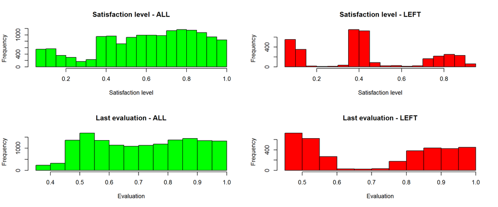

#### Average monthly working hours and number of projects

There is difference in the two group in these features as well. Those who leave work less than the average or work more than the average.

Let’s see these in numbers.  
The total number of employees in the dataset: **14999**  
The number of employees who left: **3571**  
The number of employees who work less than 150 hours: **2945**  
The number of employees who work less than 150 hours and left the company: **1059**

This means that

- about one third of those who worked less than 150 hours per month left the company later,
- about one third of the leaving employees worked less than 150 hours.

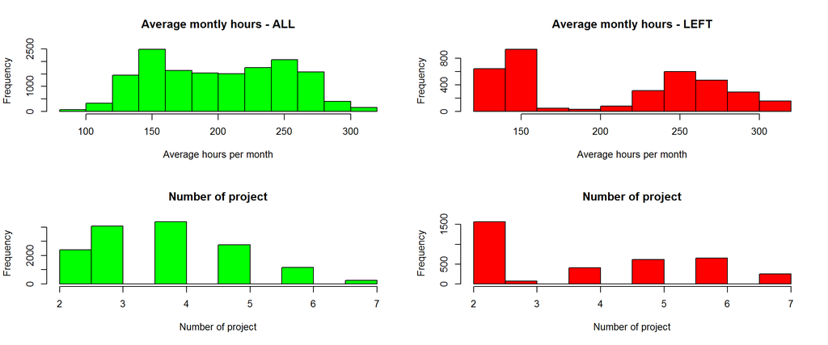

#### Time spent at the company, Promotion, Salary

The average time spent at the company is **3.4982332**. This average value in the leaving group is **3.8765052** The two numbers are fairly close to each other.  
Promotion also shows similarites.  
Regarding salary we can observe that in low and medium category people are more likely to leave than in high salary category.

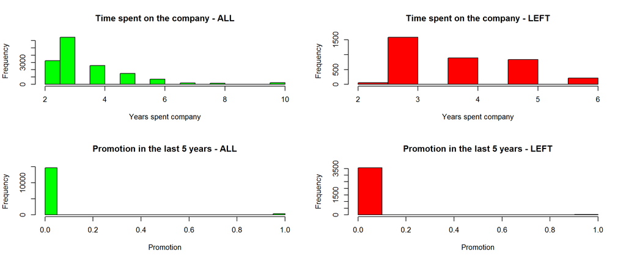

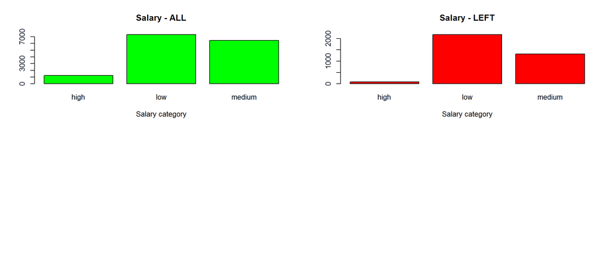

## Model predictions

In predictive modeling I chose

- Decision tree,
- GBM
- Random Forest

I split the dataset into 2 parts and I make a training set and test set. The ratio of training and test set is 60-40%.

The AUC (Area Under the Curve) is **0.9661759**, which seems to be rather good. Perhaps too good.

Let’s see which are the main driving factors in leaving the company, take a look at the decision tree.

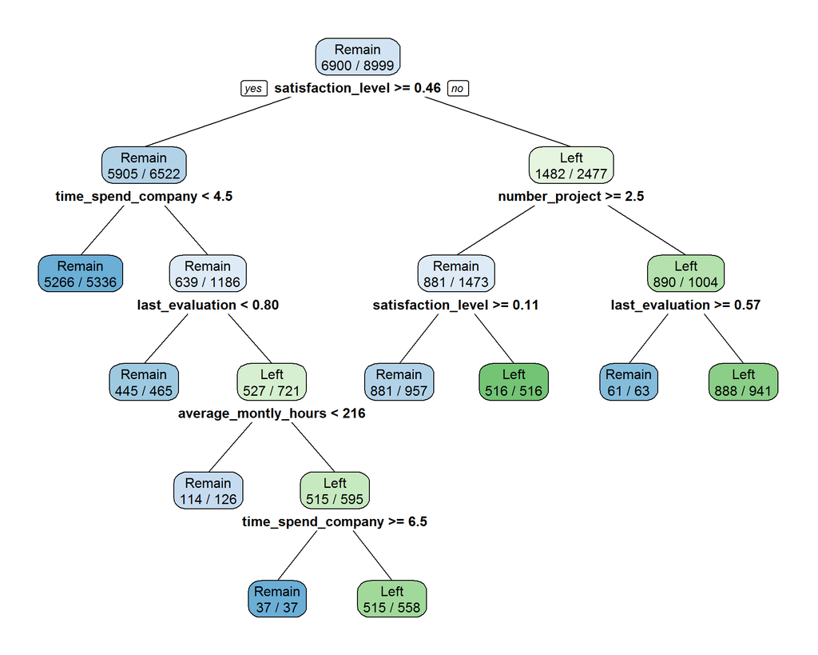

Let’s see the GBM with a confusion matrix. It seems that the confusion matrix gives relative good resuls.

|  | 0 | 1 |
| --- | --- | --- |
| **0** | 4514 | 134 |
| **1** | 14 | 1338 |

Random Forest gives even better results. The confusion matrix is bellow

|  | 0 | 1 |
| --- | --- | --- |
| **0** | 4517 | 72 |
| **1** | 11 | 1400 |

Some diagnostics

**Error Rate versus Cutoff**

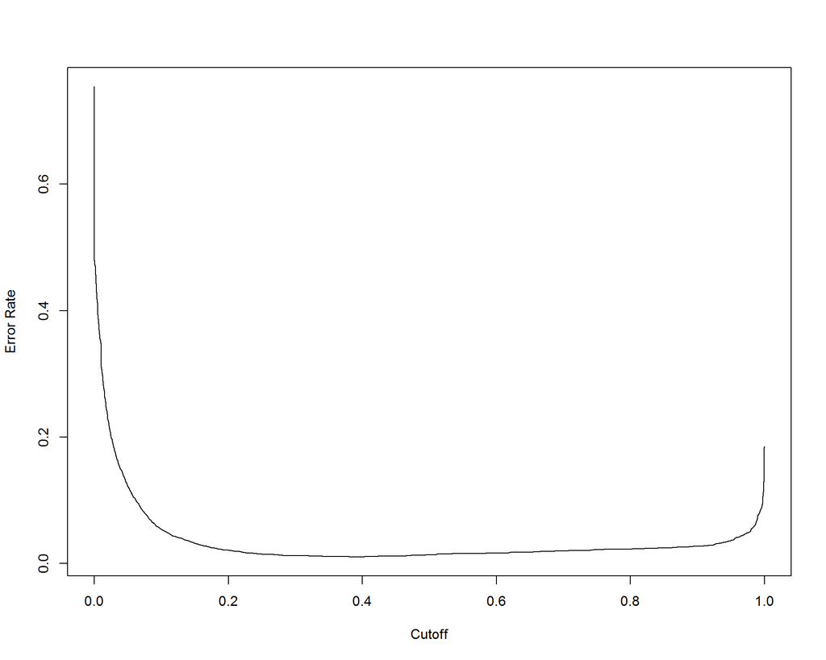

**AUC value and ROC curve**

The AUC is rather high.

```
## An object of class "performance"
## Slot "x.name":
## [1] "None"
##
## Slot "y.name":
## [1] "Area under the ROC curve"
##
## Slot "alpha.name":
## [1] "none"
##
## Slot "x.values":
## list()
##
## Slot "y.values":
## [[1]]
## [1] 0.992224
##
##
## Slot "alpha.values":
## list()
```

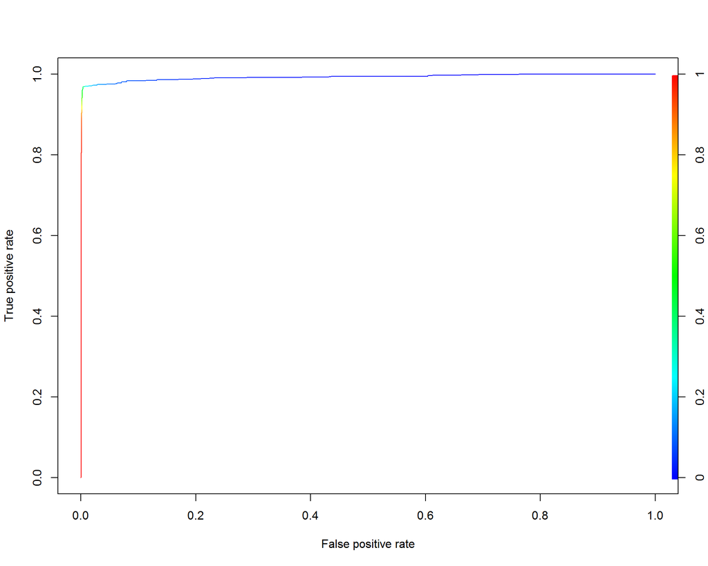

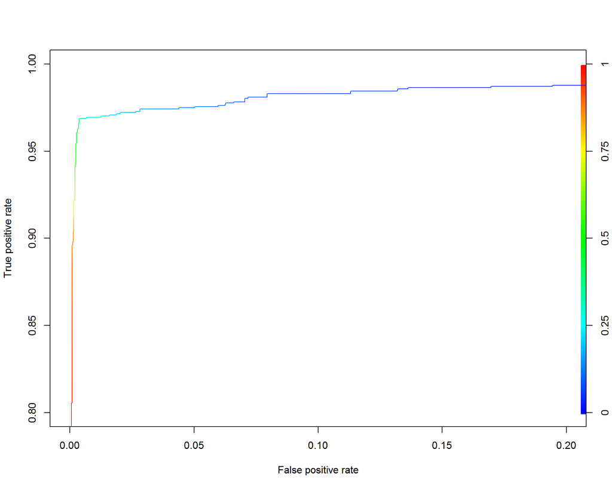

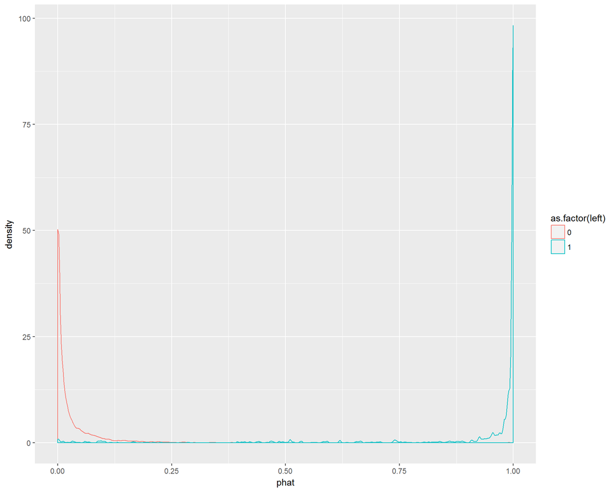